# IMPORT LIBRARIES

```python
# Required Libraries for Data Manipulation and Visualization
import pandas as pd
import numpy as np
import matplotlib.pyplot as plt
import seaborn as sns

# Libraries for Model Selection and Evaluation
from sklearn.model_selection import train_test_split, KFold, GridSearchCV
from sklearn.metrics import mean_absolute_error
from sklearn.metrics import mean_squared_error
from sklearn.metrics import r2_score
from sklearn.metrics import root_mean_squared_error

# Machine Learning Models
from sklearn.linear_model import LinearRegression
from sklearn.ensemble import RandomForestRegressor
from sklearn.svm import SVR

# XGBoost
from xgboost import XGBRegressor

# Preprocessing Tools
from sklearn.preprocessing import LabelEncoder, StandardScaler, OneHotEncoder
from sklearn.compose import ColumnTransformer

# Visualization Tools
from sklearn.tree import plot_tree

# Utility Libraries
from datetime import datetime
```

# DATASET INFORMATION

```python
#Load the dataset
data = pd.read_csv('dataset.csv')
```

```python
#Print the first 5 rows of the dataset
data.head()
```

|  | date | price | bedrooms | bathrooms | sqft_living | sqft_lot | floors | waterfront | view | condition | sqft_above | sqft_basement | yr_built | yr_renovated | street | city | statezip | country |
| --- | --- | --- | --- | --- | --- | --- | --- | --- | --- | --- | --- | --- | --- | --- | --- | --- | --- | --- |
| 0 | 5/2/2014 0:00 | 313000.0 | 3 | 1.50 | 1340 | 7912 | 1.5 | 0 | 0 | 3 | 1340 | 0 | 1955 | 2005 | 18810 Densmore Ave N | Shoreline | WA 98133 | USA |
| 1 | 5/2/2014 0:00 | 2384000.0 | 5 | 2.50 | 3650 | 9050 | 2.0 | 0 | 4 | 5 | 3370 | 280 | 1921 | 0 | 709 W Blaine St | Seattle | WA 98119 | USA |
| 2 | 5/2/2014 0:00 | 342000.0 | 3 | 2.00 | 1930 | 11947 | 1.0 | 0 | 0 | 4 | 1930 | 0 | 1966 | 0 | 26206-26214 143rd Ave SE | Kent | WA 98042 | USA |
| 3 | 5/2/2014 0:00 | 420000.0 | 3 | 2.25 | 2000 | 8030 | 1.0 | 0 | 0 | 4 | 1000 | 1000 | 1963 | 0 | 857 170th Pl NE | Bellevue | WA 98008 | USA |
| 4 | 5/2/2014 0:00 | 550000.0 | 4 | 2.50 | 1940 | 10500 | 1.0 | 0 | 0 | 4 | 1140 | 800 | 1976 | 1992 | 9105 170th Ave NE | Redmond | WA 98052 | USA |

```python
#Print the columns of the dataset
data.columns
```

```
Index(['date', 'price', 'bedrooms', 'bathrooms', 'sqft_living', 'sqft_lot',
       'floors', 'waterfront', 'view', 'condition', 'sqft_above',
       'sqft_basement', 'yr_built', 'yr_renovated', 'street', 'city',
       'statezip', 'country'],
      dtype='object')
```

# Exploratory Data Analysis

```python
#Print the information of the dataset
data.info()
```

```
<class 'pandas.core.frame.DataFrame'>
RangeIndex: 4600 entries, 0 to 4599
Data columns (total 18 columns):
 #   Column         Non-Null Count  Dtype
---  ------         --------------  -----
 0   date           4600 non-null   object
 1   price          4600 non-null   float64
 2   bedrooms       4600 non-null   int64
 3   bathrooms      4600 non-null   float64
 4   sqft_living    4600 non-null   int64
 5   sqft_lot       4600 non-null   int64
 6   floors         4600 non-null   float64
 7   waterfront     4600 non-null   int64
 8   view           4600 non-null   int64
 9   condition      4600 non-null   int64
 10  sqft_above     4600 non-null   int64
 11  sqft_basement  4600 non-null   int64
 12  yr_built       4600 non-null   int64
 13  yr_renovated   4600 non-null   int64
 14  street         4600 non-null   object
 15  city           4600 non-null   object
 16  statezip       4600 non-null   object
 17  country        4600 non-null   object
dtypes: float64(3), int64(10), object(5)
memory usage: 647.0+ KB
```

```python
#Print the description of the dataset
data.describe()
```

|  | price | bedrooms | bathrooms | sqft_living | sqft_lot | floors | waterfront | view | condition | sqft_above | sqft_basement | yr_built | yr_renovated |
| --- | --- | --- | --- | --- | --- | --- | --- | --- | --- | --- | --- | --- | --- |
| count | 4.600000e+03 | 4600.000000 | 4600.000000 | 4600.000000 | 4.600000e+03 | 4600.000000 | 4600.000000 | 4600.000000 | 4600.000000 | 4600.000000 | 4600.000000 | 4600.000000 | 4600.000000 |
| mean | 5.519630e+05 | 3.400870 | 2.160815 | 2139.346957 | 1.485252e+04 | 1.512065 | 0.007174 | 0.240652 | 3.451739 | 1827.265435 | 312.081522 | 1970.786304 | 808.608261 |
| std | 5.638347e+05 | 0.908848 | 0.783781 | 963.206916 | 3.588444e+04 | 0.538288 | 0.084404 | 0.778405 | 0.677230 | 862.168977 | 464.137228 | 29.731848 | 979.414536 |
| min | 0.000000e+00 | 0.000000 | 0.000000 | 370.000000 | 6.380000e+02 | 1.000000 | 0.000000 | 0.000000 | 1.000000 | 370.000000 | 0.000000 | 1900.000000 | 0.000000 |
| 25% | 3.228750e+05 | 3.000000 | 1.750000 | 1460.000000 | 5.000750e+03 | 1.000000 | 0.000000 | 0.000000 | 3.000000 | 1190.000000 | 0.000000 | 1951.000000 | 0.000000 |
| 50% | 4.609435e+05 | 3.000000 | 2.250000 | 1980.000000 | 7.683000e+03 | 1.500000 | 0.000000 | 0.000000 | 3.000000 | 1590.000000 | 0.000000 | 1976.000000 | 0.000000 |
| 75% | 6.549625e+05 | 4.000000 | 2.500000 | 2620.000000 | 1.100125e+04 | 2.000000 | 0.000000 | 0.000000 | 4.000000 | 2300.000000 | 610.000000 | 1997.000000 | 1999.000000 |
| max | 2.659000e+07 | 9.000000 | 8.000000 | 13540.000000 | 1.074218e+06 | 3.500000 | 1.000000 | 4.000000 | 5.000000 | 9410.000000 | 4820.000000 | 2014.000000 | 2014.000000 |

```python
#Remove NaN values
data.dropna(inplace=True)
```

```python
#Check for missing values
data.isna().sum()
```

```
date             0
price            0
bedrooms         0
bathrooms        0
sqft_living      0
sqft_lot         0
floors           0
waterfront       0
view             0
condition        0
sqft_above       0
sqft_basement    0
yr_built         0
yr_renovated     0
street           0
city             0
statezip         0
country          0
dtype: int64
```

```python
#Check for data types
data.dtypes
```

```
date              object
price            float64
bedrooms           int64
bathrooms        float64
sqft_living        int64
sqft_lot           int64
floors           float64
waterfront         int64
view               int64
condition          int64
sqft_above         int64
sqft_basement      int64
yr_built           int64
yr_renovated       int64
street            object
city              object
statezip          object
country           object
dtype: object
```

## Checking 0 in all the columns

Since the is na did not give any result. We will check if the any of the columns 0 values in the dataset

```python
#Check the 0 value in price columns
zero_price_count = data[data['price'] == 0].shape[0]
print(f"Number of rows where price is 0: {zero_price_count}")
zero_value_counts = (data == 0).sum()
print("Count of rows where value is 0 for each column:")
print(zero_value_counts)
```

```
Number of rows where price is 0: 49
Count of rows where value is 0 for each column:
date                0
price              49
bedrooms            2
bathrooms           2
sqft_living         0
sqft_lot            0
floors              0
waterfront       4567
view             4140
condition           0
sqft_above          0
sqft_basement    2745
yr_built            0
yr_renovated     2735
street              0
city                0
statezip            0
country             0
dtype: int64
```

### Removing the 0 value in the price column

```python
# Remove rows where price is 0
data = data[data['price'] != 0]
```

### Checking 0 again in all the columns

```python
#Check the 0 value in price columns as well as other columns
zero_price_count = data[data['price'] == 0].shape[0]
print(f"Number of rows where price is 0: {zero_price_count}")
zero_value_counts = (data == 0).sum()
print("Count of rows where value is 0 for each column:")
print(zero_value_counts)
```

```
Number of rows where price is 0: 0
Count of rows where value is 0 for each column:
date                0
price               0
bedrooms            2
bathrooms           2
sqft_living         0
sqft_lot            0
floors              0
waterfront       4521
view             4103
condition           0
sqft_above          0
sqft_basement    2718
yr_built            0
yr_renovated     2706
street              0
city                0
statezip            0
country             0
dtype: int64
```

### Removing the 0 in bedroom and bathroom

```python
#Remove rows where bedrooms or bathrooms are 0
data = data[(data['bedrooms'] > 0) & (data['bathrooms'] > 0)]
```

### Checking the 0 value again in all the columns after removing from price, bedroom and bathroom

```python
#Check the 0 value in price columns
zero_price_count = data[data['price'] == 0].shape[0]
print(f"Number of rows where price is 0: {zero_price_count}")
zero_value_counts = (data == 0).sum()
print("Count of rows where value is 0 for each column:")
print(zero_value_counts)
```

```
Number of rows where price is 0: 0
Count of rows where value is 0 for each column:
date                0
price               0
bedrooms            0
bathrooms           0
sqft_living         0
sqft_lot            0
floors              0
waterfront       4519
view             4102
condition           0
sqft_above          0
sqft_basement    2716
yr_built            0
yr_renovated     2706
street              0
city                0
statezip            0
country             0
dtype: int64
```

We have removed the 0 value from the price, bedroom and bathroom as there cannot be any houses with 0 bedroom, bathroom and price. We are not removing other 0 values from other columns as they can differ from house to house

Here in the following, we are calculating the age of the house, years since last renovation and some other info as they will give better insights about the dataset and houses.

```python
# Get the current year
current_year = datetime.now().year

# 1. House Age
data['age_of_house'] = current_year - data['yr_built']

# 2. Time Since Last Renovation
data['years_since_last_renovation'] = np.where(data['yr_renovated'] == 0, 0, current_year - data['yr_renovated'])

# 3. Price per Square Foot
data['price_per_sqft_living'] = data['price'] / data['sqft_living']

# 4. Lot Size vs Living Space Ratio
data['lot_vs_living'] = data['sqft_lot'] / data['sqft_living']

# 5. Above Ground Space to Total Living Space Ratio
data['above_to_living_ratio'] = data['sqft_above'] / data['sqft_living']
```

```python
#Print the first 5 rows of the dataset
data.head()
```

|  | date | price | bedrooms | bathrooms | sqft_living | sqft_lot | floors | waterfront | view | condition | ... | yr_renovated | street | city | statezip | country | age_of_house | years_since_last_renovation | price_per_sqft_living | lot_vs_living | above_to_living_ratio |
| --- | --- | --- | --- | --- | --- | --- | --- | --- | --- | --- | --- | --- | --- | --- | --- | --- | --- | --- | --- | --- | --- |
| 0 | 5/2/2014 0:00 | 313000.0 | 3 | 1.50 | 1340 | 7912 | 1.5 | 0 | 0 | 3 | ... | 2005 | 18810 Densmore Ave N | Shoreline | WA 98133 | USA | 70 | 20 | 233.582090 | 5.904478 | 1.000000 |
| 1 | 5/2/2014 0:00 | 2384000.0 | 5 | 2.50 | 3650 | 9050 | 2.0 | 0 | 4 | 5 | ... | 0 | 709 W Blaine St | Seattle | WA 98119 | USA | 104 | 0 | 653.150685 | 2.479452 | 0.923288 |
| 2 | 5/2/2014 0:00 | 342000.0 | 3 | 2.00 | 1930 | 11947 | 1.0 | 0 | 0 | 4 | ... | 0 | 26206-26214 143rd Ave SE | Kent | WA 98042 | USA | 59 | 0 | 177.202073 | 6.190155 | 1.000000 |
| 3 | 5/2/2014 0:00 | 420000.0 | 3 | 2.25 | 2000 | 8030 | 1.0 | 0 | 0 | 4 | ... | 0 | 857 170th Pl NE | Bellevue | WA 98008 | USA | 62 | 0 | 210.000000 | 4.015000 | 0.500000 |
| 4 | 5/2/2014 0:00 | 550000.0 | 4 | 2.50 | 1940 | 10500 | 1.0 | 0 | 0 | 4 | ... | 1992 | 9105 170th Ave NE | Redmond | WA 98052 | USA | 49 | 33 | 283.505155 | 5.412371 | 0.587629 |

5 rows × 23 columns

```python
#Print the columns of the dataset
data.columns
```

```
Index(['date', 'price', 'bedrooms', 'bathrooms', 'sqft_living', 'sqft_lot',
       'floors', 'waterfront', 'view', 'condition', 'sqft_above',
       'sqft_basement', 'yr_built', 'yr_renovated', 'street', 'city',
       'statezip', 'country', 'age_of_house', 'years_since_last_renovation',
       'price_per_sqft_living', 'lot_vs_living', 'above_to_living_ratio'],
      dtype='object')
```

### As we head to the price prediction, we need to ensure that irrelevant column are removed so that the result will be better.

```python
#Remove columns that are not needed
new_data = data.drop(['statezip', 'yr_built', 'yr_renovated','city','street','date','sqft_living','sqft_lot','sqft_above'], axis=1)
```

```python
new_data.dtypes
```

```
price                          float64
bedrooms                         int64
bathrooms                      float64
floors                         float64
waterfront                       int64
view                             int64
condition                        int64
sqft_basement                    int64
country                         object
age_of_house                     int64
years_since_last_renovation      int64
price_per_sqft_living          float64
lot_vs_living                  float64
above_to_living_ratio          float64
dtype: object
```

```python
#Print the first 5 rows of the new dataset
new_data.head(5)
```

|  | price | bedrooms | bathrooms | floors | waterfront | view | condition | sqft_basement | country | age_of_house | years_since_last_renovation | price_per_sqft_living | lot_vs_living | above_to_living_ratio |
| --- | --- | --- | --- | --- | --- | --- | --- | --- | --- | --- | --- | --- | --- | --- |
| 0 | 313000.0 | 3 | 1.50 | 1.5 | 0 | 0 | 3 | 0 | USA | 70 | 20 | 233.582090 | 5.904478 | 1.000000 |
| 1 | 2384000.0 | 5 | 2.50 | 2.0 | 0 | 4 | 5 | 280 | USA | 104 | 0 | 653.150685 | 2.479452 | 0.923288 |
| 2 | 342000.0 | 3 | 2.00 | 1.0 | 0 | 0 | 4 | 0 | USA | 59 | 0 | 177.202073 | 6.190155 | 1.000000 |
| 3 | 420000.0 | 3 | 2.25 | 1.0 | 0 | 0 | 4 | 1000 | USA | 62 | 0 | 210.000000 | 4.015000 | 0.500000 |
| 4 | 550000.0 | 4 | 2.50 | 1.0 | 0 | 0 | 4 | 800 | USA | 49 | 33 | 283.505155 | 5.412371 | 0.587629 |

```python
#Print the columns of the new dataset
new_data.columns
```

```
Index(['price', 'bedrooms', 'bathrooms', 'floors', 'waterfront', 'view',
       'condition', 'sqft_basement', 'country', 'age_of_house',
       'years_since_last_renovation', 'price_per_sqft_living', 'lot_vs_living',
       'above_to_living_ratio'],
      dtype='object')
```

### Correlation Heatmap After Removing the Irrelevant columns

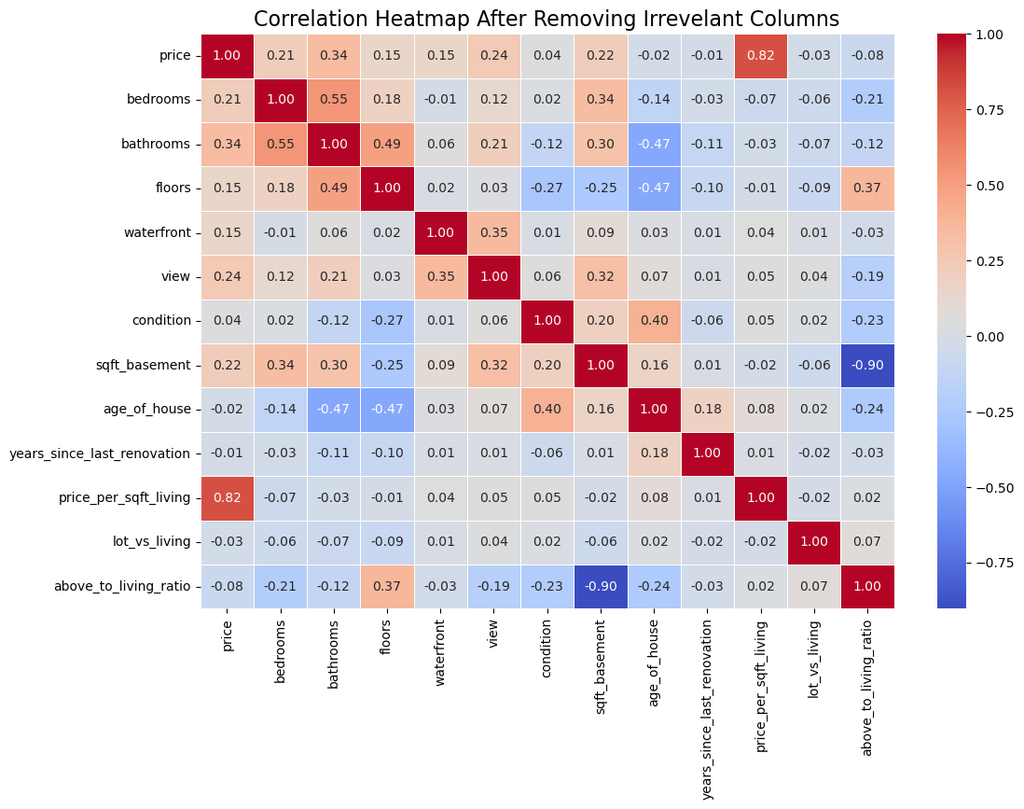

```python
# Drp non-numeric columns
new_data_numeric = new_data.select_dtypes(include=[np.number])

# Compute the correlation matrix
correlation_matrix = new_data_numeric.corr()

# Plot the heatmap
plt.figure(figsize=(12, 8))
sns.heatmap(correlation_matrix, annot=True, cmap="coolwarm", fmt=".2f", linewidths=0.5)
plt.title("Correlation Heatmap After Removing Irrevelant Columns", fontsize=16)
plt.show()
```

# Checking for Outliers and BoxPlot them

```
Outlier Count Summary:
bedrooms: 113 outliers
bathrooms: 128 outliers
floors: 0 outliers
waterfront: 30 outliers
view: 447 outliers
condition: 6 outliers
sqft_basement: 83 outliers
age_of_house: 0 outliers
years_since_last_renovation: 168 outliers
price_per_sqft_living: 136 outliers
lot_vs_living: 418 outliers
above_to_living_ratio: 0 outliers
```

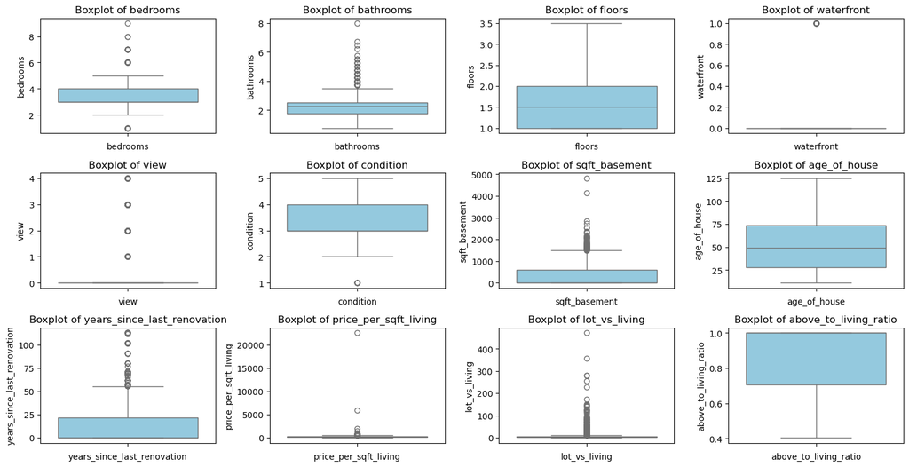

```python
# Numerical columns
numerical_columns = [
    'bedrooms', 'bathrooms', 'floors', 'waterfront', 'view',
    'condition', 'sqft_basement', 'age_of_house',
    'years_since_last_renovation', 'price_per_sqft_living', 'lot_vs_living',
    'above_to_living_ratio'
]

# Step 1: Calculate IQR for each numerical column
outlier_summary = {}
for col in numerical_columns:
    Q1 = new_data[col].quantile(0.25)
    Q3 = new_data[col].quantile(0.75)
    IQR = Q3 - Q1
    lower_bound = Q1 - 1.5 * IQR
    upper_bound = Q3 + 1.5 * IQR
    outliers = new_data[(new_data[col] < lower_bound) | (new_data[col] > upper_bound)]
    outlier_summary[col] = len(outliers)

# Step 2: Print outlier counts for each column
print("Outlier Count Summary:")
for col, count in outlier_summary.items():
    print(f"{col}: {count} outliers")

# Step 3: Visualize with box plots
plt.figure(figsize=(15, 10))
for i, col in enumerate(numerical_columns, 1):
    plt.subplot(4, 4, i)
    sns.boxplot(new_data[col], color="skyblue")
    plt.title(f"Boxplot of {col}")
    plt.xlabel(col)
plt.tight_layout()
plt.show()
```

# Removing the Outliers

```
Data shape after removing outliers: (3296, 14)
```

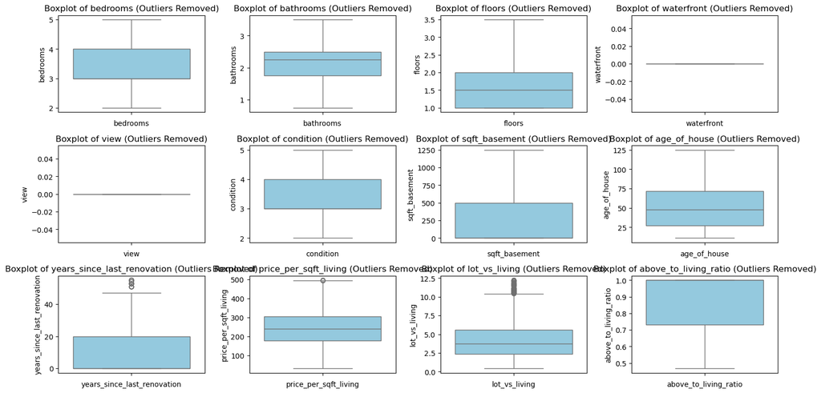

```python
# Columns with outliers
columns_with_outliers = [
    'bedrooms', 'bathrooms', 'floors', 'waterfront', 'view',
    'condition', 'sqft_basement', 'age_of_house',
    'years_since_last_renovation', 'price_per_sqft_living', 'lot_vs_living',
    'above_to_living_ratio'
]

# Remove outliers
for col in columns_with_outliers:
    Q1 = new_data[col].quantile(0.25)
    Q3 = new_data[col].quantile(0.75)
    IQR = Q3 - Q1
    lower_bound = Q1 - 1.5 * IQR
    upper_bound = Q3 + 1.5 * IQR
    # Filter rows within the IQR bounds
    new_data = new_data[(new_data[col] >= lower_bound) & (new_data[col] <= upper_bound)]

# Print the remaining data shape
print(f"Data shape after removing outliers: {new_data.shape}")

# Visualize again with box plots to verify outliers are removed
plt.figure(figsize=(15, 10))
for i, col in enumerate(columns_with_outliers, 1):
    plt.subplot(4, 4, i)
    sns.boxplot(new_data[col], color="skyblue")
    plt.title(f"Boxplot of {col} (Outliers Removed)")
    plt.xlabel(col)
plt.tight_layout()
plt.show()
```

```python
new_data.columns
new_data.dtypes
```

```
price                          float64
bedrooms                         int64
bathrooms                      float64
floors                         float64
waterfront                       int64
view                             int64
condition                        int64
sqft_basement                    int64
country                         object
age_of_house                     int64
years_since_last_renovation      int64
price_per_sqft_living          float64
lot_vs_living                  float64
above_to_living_ratio          float64
dtype: object
```

```python
import pandas as pd

# Assuming your DataFrame is named 'new_data'
# Identifying categorical columns
categorical_columns = ['country']

# Applying One-Hot Encoding to categorical columns
df_encoded = pd.get_dummies(new_data, columns=categorical_columns, drop_first=True)

# Display the first few rows of the updated DataFrame
print(df_encoded.head())
```

```
      price  bedrooms  bathrooms  floors  waterfront  view  condition  \
0  313000.0         3       1.50     1.5           0     0          3
2  342000.0         3       2.00     1.0           0     0          4
3  420000.0         3       2.25     1.0           0     0          4
4  550000.0         4       2.50     1.0           0     0          4
6  335000.0         2       2.00     1.0           0     0          3

   sqft_basement  age_of_house  years_since_last_renovation  \
0              0            70                           20
2              0            59                            0
3           1000            62                            0
4            800            49                           33
6              0            49                            0

   price_per_sqft_living  lot_vs_living  above_to_living_ratio
0             233.582090       5.904478               1.000000
2             177.202073       6.190155               1.000000
3             210.000000       4.015000               0.500000
4             283.505155       5.412371               0.587629
6             248.148148       1.896296               1.000000
```

# MODEL TRAINING

### Here we will split the dataset into X and y for the model training training.

```python
#Define the target and features.
X = df_encoded.drop('price', axis=1)
y = df_encoded['price']
```

```python
#Split the data into training and testing sets.
X_train, X_test, y_train, y_test = train_test_split(X, y, test_size=0.2, random_state=42)
```

# Initialization of the Linear Regression Model

```python
linear_regression_model = LinearRegression()
```

### Checking for NaN values in the features and target before training the model

```python
# # Check for NaN values in features and target
# print("NaN values in X:")
# print(X.isna().sum())

# print("\nNaN values in y:")
# print(y.isna().sum())

# # Select only numeric columns from X
# numeric_X = X.select_dtypes(include=[np.number])

# # Check for infinite values in numeric columns
# print("\nInfinite values in numeric X:")
# print(np.isinf(numeric_X).sum())
```

```python
# #To Identify columns in the X_train DataFrame containing categorical data.
# categorical_columns = X_train.select_dtypes(include=['object']).columns
```

```python
# label_encoder = LabelEncoder()
# for col in categorical_columns:
#     X_train[col] = label_encoder.fit_transform(X_train[col])
#     X_test[col] = label_encoder.transform(X_test[col])
```

```python
#The code ensures that both feature and target  has the same columns and handling any missing columns
# by adding them with default values to maintain consistency for model predictions.
missing_cols = set(X_train.columns) - set(X_test.columns)
for col in missing_cols:
    X_test[col] = 0  # Add missing columns with default values

X_test = X_test[X_train.columns]  # Reorder columns to match X_train
```

```python
# Check for missing values in both X_train and X_test
missing_values_train = X_train.isnull().sum()
missing_values_test = X_test.isnull().sum()

missing_values_train, missing_values_test
```

```
(bedrooms                       0
 bathrooms                      0
 floors                         0
 waterfront                     0
 view                           0
 condition                      0
 sqft_basement                  0
 age_of_house                   0
 years_since_last_renovation    0
 price_per_sqft_living          0
 lot_vs_living                  0
 above_to_living_ratio          0
 dtype: int64,
 bedrooms                       0
 bathrooms                      0
 floors                         0
 waterfront                     0
 view                           0
 condition                      0
 sqft_basement                  0
 age_of_house                   0
 years_since_last_renovation    0
 price_per_sqft_living          0
 lot_vs_living                  0
 above_to_living_ratio          0
 dtype: int64)
```

# Linear Regression Model

```python
linear_regression_model = LinearRegression()
linear_regression_model.fit(X_train, y_train)
```

```
LinearRegression()
```

## Initialization the prediction of the Linear Regression Model

```python
#Predict the target on the test set
y_pred = linear_regression_model.predict(X_test)
```

## Evaluating the Linear Regression Model with Performance Metrices

```python
# Calculate metrics
mse = mean_squared_error(y_test, y_pred)
rmse = np.sqrt(mse)  # Root Mean Squared Error
mae = mean_absolute_error(y_test, y_pred)
r2 = r2_score(y_test, y_pred)

# Print results
print(f"Linear Regression Model Evaluation:")
print(f"Mean Squared Error (MSE) of Linear Regression: {mse:.2f}")
print(f"Root Mean Squared Error (RMSE) Linear Regression: {rmse:.2f}")
print(f"Mean Absolute Error (MAE) Linear Regression: {mae:.2f}")
print(f"R-squared Score (R²) Linear Regression: {r2:.2f}")
```

```
Linear Regression Model Evaluation:
Mean Squared Error (MSE) of Linear Regression: 15408191457.75
Root Mean Squared Error (RMSE) Linear Regression: 124129.74
Mean Absolute Error (MAE) Linear Regression: 94756.59
R-squared Score (R²) Linear Regression: 0.69
```

# Initialization the XGBoost Model

```python
# Initialize XGBoost model
xgboost_model = XGBRegressor(n_estimators=100, learning_rate=0.1, max_depth=6, random_state=42)

# Fit the XGBoost model
xgboost_model.fit(X_train, y_train)
```

```
XGBRegressor(base_score=None, booster=None, callbacks=None,
             colsample_bylevel=None, colsample_bynode=None,
             colsample_bytree=None, device=None, early_stopping_rounds=None,
             enable_categorical=False, eval_metric=None, feature_types=None,
             gamma=None, grow_policy=None, importance_type=None,
             interaction_constraints=None, learning_rate=0.1, max_bin=None,
             max_cat_threshold=None, max_cat_to_onehot=None,
             max_delta_step=None, max_depth=6, max_leaves=None,
             min_child_weight=None, missing=nan, monotone_constraints=None,
             multi_strategy=None, n_estimators=100, n_jobs=None,
             num_parallel_tree=None, random_state=42, ...)
```

## Predict the target on the test Set

```python
# Predict the target on the test set
y_pred_xgb = xgboost_model.predict(X_test)
```

## Evaluate the Model with Performance Metrices

```python
# Calculate metrics for XGBoost
mse_xgb = mean_squared_error(y_test, y_pred_xgb)
rmse_xgb = np.sqrt(mse_xgb)
mae_xgb = mean_absolute_error(y_test, y_pred_xgb)
r2_xgb = r2_score(y_test, y_pred_xgb)

# Print results for XGBoost
print("\nXGBoost Model Evaluation:")
print(f"Mean Squared Error (MSE) of XGBoost: {mse_xgb:.2f}")
print(f"Root Mean Squared Error (RMSE) XGBoost: {rmse_xgb:.2f}")
print(f"Mean Absolute Error (MAE) XGBoost: {mae_xgb:.2f}")
print(f"R-squared Score (R²) XGBoost: {r2_xgb:.2f}")
```

```
XGBoost Model Evaluation:
Mean Squared Error (MSE) of XGBoost: 8807967743.97
Root Mean Squared Error (RMSE) XGBoost: 93850.77
Mean Absolute Error (MAE) XGBoost: 64194.48
R-squared Score (R²) XGBoost: 0.82
```

# SVM Model

```python
# Create and train the SVM model
svm_model = SVR(kernel='rbf', C=1.0, epsilon=0.1)  # You can adjust hyperparameters
svm_model.fit(X_train, y_train)
```

```
SVR()
```

# Predict the Data

```python
# Predict the target on the test set
y_pred_svm = svm_model.predict(X_test)
```

## Evaluate the Model with Performance Metrices

```python
# Evaluate the SVM model
mse_svm = mean_squared_error(y_test, y_pred_svm)
rmse_svm = np.sqrt(mse_svm)
mae_svm = mean_absolute_error(y_test, y_pred_svm)
r2_svm = r2_score(y_test, y_pred_svm)

# Print results for SVM
print("SVM Model Evaluation:")
print(f"Mean Squared Error (MSE): {mse_svm:.2f}")
print(f"Root Mean Squared Error (RMSE): {rmse_svm:.2f}")
print(f"Mean Absolute Error (MAE): {mae_svm:.2f}")
print(f"R-squared Score (R²): {r2_svm:.2f}")
```

```
SVM Model Evaluation:
Mean Squared Error (MSE): 52567173432.62
Root Mean Squared Error (RMSE): 229275.32
Mean Absolute Error (MAE): 171561.82
R-squared Score (R²): -0.05
```

# Random Forest Model

```python
# Create and train the Random Forest model
random_forest_model = RandomForestRegressor(n_estimators=100, random_state=42)  # Adjust n_estimators as needed
random_forest_model.fit(X_train, y_train)
```

```
RandomForestRegressor(random_state=42)
```

# Make Prediction with Random Forest

```python
# Make predictions with Random Forest
y_pred_rf = random_forest_model.predict(X_test)
```

# Evaluate the Model with Performance Metrices

```python
# Evaluate the Random Forest model
mse_rf = mean_squared_error(y_test, y_pred_rf)
rmse_rf = np.sqrt(mse_rf)
mae_rf = mean_absolute_error(y_test, y_pred_rf)
r2_rf = r2_score(y_test, y_pred_rf)

# Print results for Random Forest
print("\nRandom Forest Model Evaluation:")
print(f"Mean Squared Error (MSE): {mse_rf:.2f}")
print(f"Root Mean Squared Error (RMSE): {rmse_rf:.2f}")
print(f"Mean Absolute Error (MAE): {mae_rf:.2f}")
print(f"R-squared Score (R²): {r2_rf:.2f}")
```

```
Random Forest Model Evaluation:
Mean Squared Error (MSE): 10457612543.14
Root Mean Squared Error (RMSE): 102262.47
Mean Absolute Error (MAE): 71588.56
R-squared Score (R²): 0.79
```

# SCATTER PLOT

```python
# # Dictionary to store models and predictions
# models = {
#     "Linear Regression": linear_regression_model,
#     "XGBoost": xgboost_model,
#     "SVM": svm_model,
#     "Random Forest": random_forest_model,
# }

# predictions = {
#     "Linear Regression": y_pred,
#     "XGBoost": y_pred_xgb,
#     "SVM": y_pred_svm,
#     "Random Forest": y_pred_rf,
# }

# # Plotting scatter plots
# fig, axes = plt.subplots(2, 2, figsize=(20, 18))

# for i, (model_name, pred) in enumerate(predictions.items()):
#     ax = axes[i // 2, i % 2]
#     sns.scatterplot(x=y_test, y=pred, alpha=0.7, ax=ax, color='blue')
#     ax.plot([y_test.min(), y_test.max()], [y_test.min(), y_test.max()], color="red", linestyle="--")
#     ax.set_title(f"Scatter Plot for {model_name}", fontsize=16)
#     ax.set_xlabel("Actual Values", fontsize=14)
#     ax.set_ylabel("Predicted Values", fontsize=14)
#     ax.grid(True)

# plt.tight_layout()
# plt.show()
```

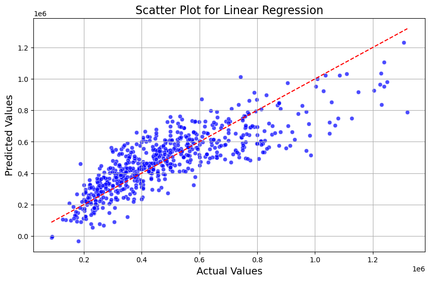

```python
# Linear Regression Model
plt.figure(figsize=(10, 6))
sns.scatterplot(x=y_test, y=y_pred, alpha=0.7, color='blue')
plt.plot([y_test.min(), y_test.max()], [y_test.min(), y_test.max()], color="red", linestyle="--")
plt.title("Scatter Plot for Linear Regression", fontsize=16)
plt.xlabel("Actual Values", fontsize=14)
plt.ylabel("Predicted Values", fontsize=14)
plt.grid(True)
plt.show()
```

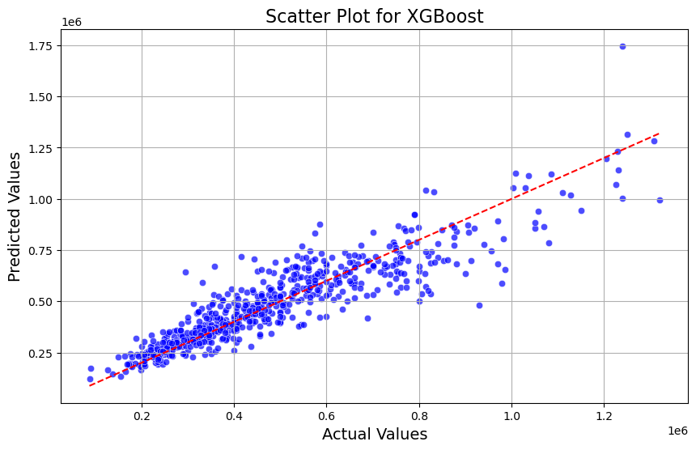

```python
# XGBoost Model
plt.figure(figsize=(10, 6))
sns.scatterplot(x=y_test, y=y_pred_xgb, alpha=0.7, color='blue')
plt.plot([y_test.min(), y_test.max()], [y_test.min(), y_test.max()], color="red", linestyle="--")
plt.title("Scatter Plot for XGBoost", fontsize=16)
plt.xlabel("Actual Values", fontsize=14)
plt.ylabel("Predicted Values", fontsize=14)
plt.grid(True)
plt.show()
```

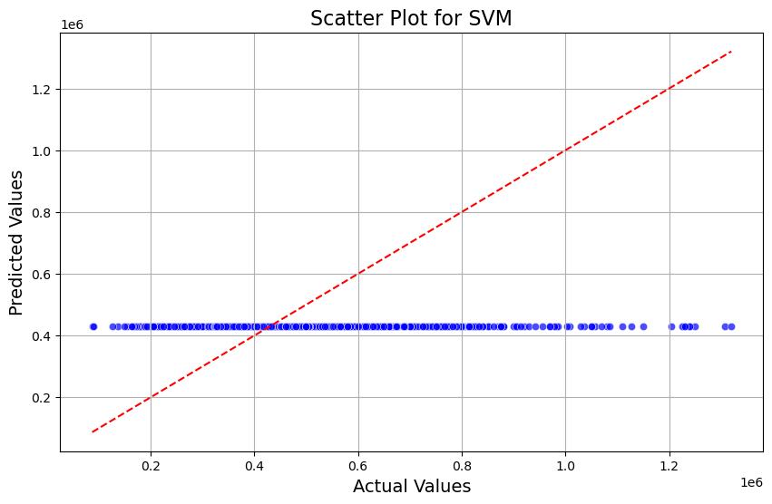

```python
# SVM Model
plt.figure(figsize=(10, 6))
sns.scatterplot(x=y_test, y=y_pred_svm, alpha=0.7, color='blue')
plt.plot([y_test.min(), y_test.max()], [y_test.min(), y_test.max()], color="red", linestyle="--")
plt.title("Scatter Plot for SVM", fontsize=16)
plt.xlabel("Actual Values", fontsize=14)
plt.ylabel("Predicted Values", fontsize=14)
plt.grid(True)
plt.show()
```

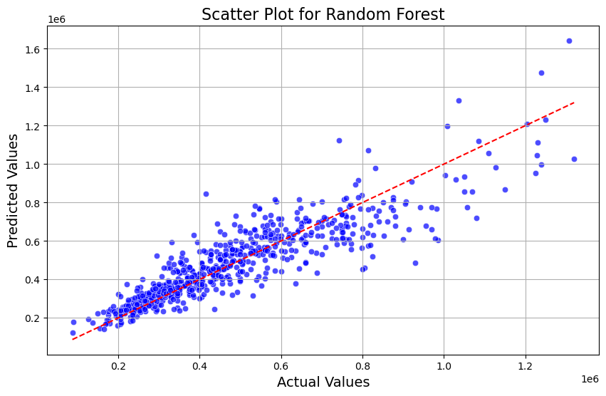

```python
# Random Forest Model
plt.figure(figsize=(10, 6))
sns.scatterplot(x=y_test, y=y_pred_rf, alpha=0.7, color='blue')
plt.plot([y_test.min(), y_test.max()], [y_test.min(), y_test.max()], color="red", linestyle="--")
plt.title("Scatter Plot for Random Forest", fontsize=16)
plt.xlabel("Actual Values", fontsize=14)
plt.ylabel("Predicted Values", fontsize=14)
plt.grid(True)
plt.show()
```

# RESIDUALS PLOT

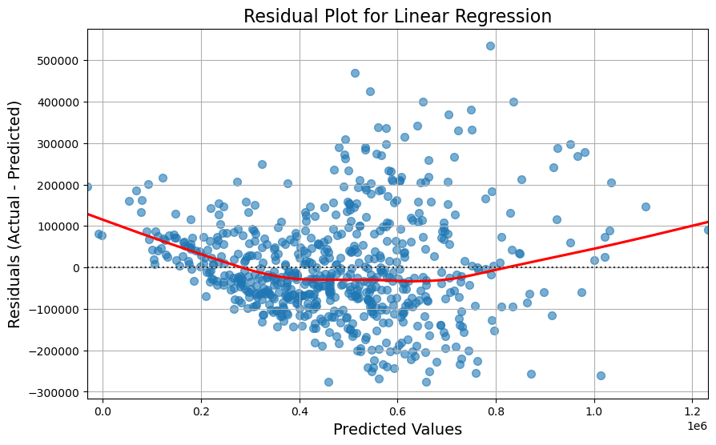

```python
# Linear Regression Residual Plot
plt.figure(figsize=(10, 6))
residuals = y_test - y_pred
sns.residplot(x=y_pred, y=residuals, lowess=True, line_kws={'color': 'red'},
              scatter_kws={'s': 50, 'alpha': 0.6})
plt.title("Residual Plot for Linear Regression", fontsize=16)
plt.xlabel("Predicted Values", fontsize=14)
plt.ylabel("Residuals (Actual - Predicted)", fontsize=14)
plt.grid(True)
plt.show()
```

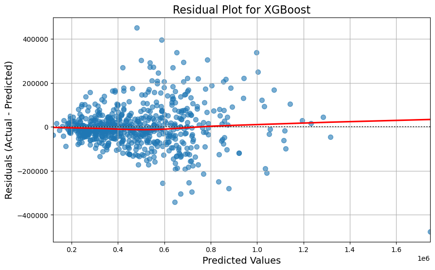

```python
# XGBoost Residual Plot
plt.figure(figsize=(10, 6))
residuals = y_test - y_pred_xgb
sns.residplot(x=y_pred_xgb, y=residuals, lowess=True, line_kws={'color': 'red'},
              scatter_kws={'s': 50, 'alpha': 0.6})
plt.title("Residual Plot for XGBoost", fontsize=16)
plt.xlabel("Predicted Values", fontsize=14)
plt.ylabel("Residuals (Actual - Predicted)", fontsize=14)
plt.grid(True)
plt.show()
```

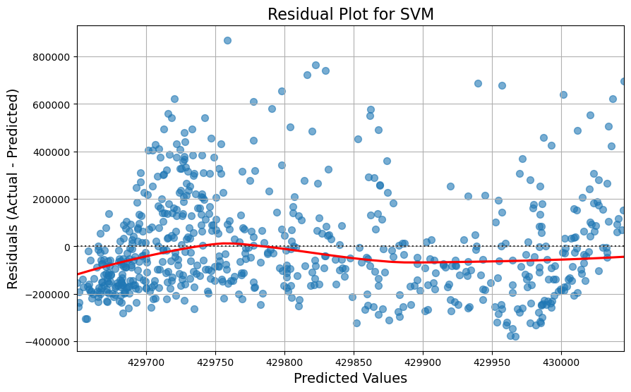

```python
# SVM Residual Plot
plt.figure(figsize=(10, 6))
residuals = y_test - y_pred_svm
sns.residplot(x=y_pred_svm, y=residuals, lowess=True, line_kws={'color': 'red'},
              scatter_kws={'s': 50, 'alpha': 0.6})
plt.title("Residual Plot for SVM", fontsize=16)
plt.xlabel("Predicted Values", fontsize=14)
plt.ylabel("Residuals (Actual - Predicted)", fontsize=14)
plt.grid(True)
plt.show()
```

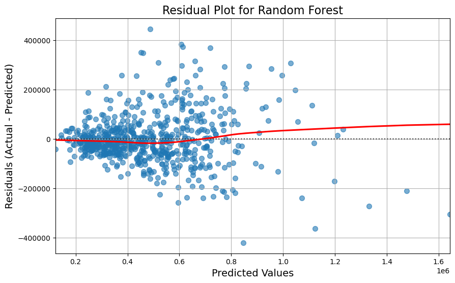

```python
# Random Forest Residual Plot
plt.figure(figsize=(10, 6))
residuals = y_test - y_pred_rf
sns.residplot(x=y_pred_rf, y=residuals, lowess=True, line_kws={'color': 'red'},
              scatter_kws={'s': 50, 'alpha': 0.6})
plt.title("Residual Plot for Random Forest", fontsize=16)
plt.xlabel("Predicted Values", fontsize=14)
plt.ylabel("Residuals (Actual - Predicted)", fontsize=14)
plt.grid(True)
plt.show()
```

```python
# # Dictionary to store models and their predictions
# models = {
#     "Linear Regression": linear_regression_model,
#     "XGBoost": xgboost_model,
#     "SVM": svm_model,
#     "Random Forest": random_forest_model,
# }

# # Predictions dictionary for residuals
# predictions = {
#     "Linear Regression": y_pred,
#     "XGBoost": y_pred_xgb,
#     "SVM": y_pred_svm,
#     "Random Forest": y_pred_rf,
# }

# # Plotting residuals
# fig, axes = plt.subplots(2, 2, figsize=(20, 18))

# for i, (model_name, pred) in enumerate(predictions.items()):
#     residuals = y_test - pred
#     ax = axes[i // 2, i % 2]
#     sns.residplot(x=pred, y=residuals, lowess=True, line_kws={'color': 'red'},
#                   scatter_kws={'s': 50, 'alpha': 0.6}, ax=ax)
#     ax.set_title(f"Residual Plot for {model_name}", fontsize=16)
#     ax.set_xlabel("Predicted Values", fontsize=14)
#     ax.set_ylabel("Residuals (Actual - Predicted)", fontsize=14)
#     ax.grid(True)

# plt.tight_layout()
# plt.show()
```

# COMPARISON OF ALL FOUR MODELS

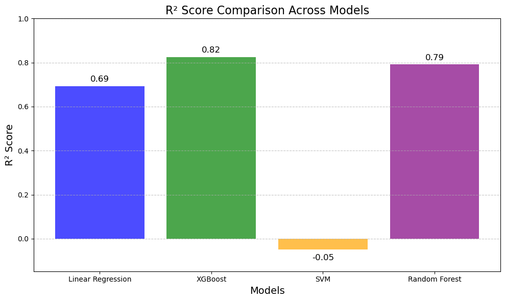

```python
# Metrics for models
metrics = {
    "Model": ["Linear Regression", "XGBoost", "SVM", "Random Forest"],
    "R²": [r2, r2_xgb, r2_svm, r2_rf],
}

# Plot bar graph for R² score
plt.figure(figsize=(10, 6))
plt.bar(metrics["Model"], metrics["R²"], color=["blue", "green", "orange", "purple"], alpha=0.7)
plt.title("R² Score Comparison Across Models", fontsize=16)
plt.ylabel("R² Score", fontsize=14)
plt.xlabel("Models", fontsize=14)
plt.ylim(min(metrics["R²"]) - 0.1, 1)
plt.grid(axis="y", linestyle="--", alpha=0.7)

# Add labels to the bars for better understanding
for i, value in enumerate(metrics["R²"]):
    plt.text(i, value + 0.02 if value >= 0 else value - 0.05, f"{value:.2f}",
             ha="center", fontsize=12, color="black")

# Show the plot
plt.tight_layout()
plt.show()
```

# K-FOLD VALIDATION OF RANDOM FOREST MODEL WITH R_2 SCORE

```python
# Features and target variable
x = new_data.drop(columns=['price'])
y = new_data['price']

# Define categorical columns
categorical_columns = ['country', 'waterfront', 'view', 'condition']

# Apply one-hot encoding to categorical features
x = pd.get_dummies(x, columns=categorical_columns, drop_first=True)

# Initialize KFold with 4 splits
kf = KFold(n_splits=4, shuffle=True, random_state=42)

# Store metrics for each fold
mse_scores = []
r2_scores = []
rmse_scores = []
index = 1

# Initialize Random Forest regression model
rf_model = RandomForestRegressor(n_estimators=100, random_state=42)
```

```python
for train_index, test_index in kf.split(x):
    # Split data into training and testing sets for this fold
    x_train, x_test = x.iloc[train_index], x.iloc[test_index]
    y_train, y_test = y.iloc[train_index], y.iloc[test_index]

    # Fit the Random Forest regression model
    rf_model.fit(x_train, y_train)

    # Make predictions
    y_pred = rf_model.predict(x_test)
```

```python
# Calculate metrics
mse = mean_squared_error(y_test, y_pred)
rmse = np.sqrt(mse)
r2 = r2_score(y_test, y_pred)

# Append metrics
mse_scores.append(mse)
rmse_scores.append(rmse)
r2_scores.append(r2)

print(f'MSE in K-Fold {index} -> {mse}')
print(f'RMSE in K-Fold {index} -> {rmse}')
print(f'R2 in K-Fold {index} -> {r2}')
index += 1
print('-' * 50)

# Print the average metrics across all folds
print(f'Average MSE across 4 folds -> {np.mean(mse_scores)}')
print(f'Average RMSE across 4 folds -> {np.mean(rmse_scores)}')
print(f'Average R2 Score across 4 folds -> {np.mean(r2_scores)}')
```

```
MSE in K-Fold 1 -> 8894098826.101305
RMSE in K-Fold 1 -> 94308.529975296
R2 in K-Fold 1 -> 0.8119928222429009
--------------------------------------------------
Average MSE across 4 folds -> 8894098826.101305
Average RMSE across 4 folds -> 94308.529975296
Average R2 Score across 4 folds -> 0.8119928222429009
```

# HYPERPARAMETER GRID TO INCREASE THE SCORE OF THE RANDOM FOREST MODEL

```python
# Split Data into Features and Target
X = new_data.drop(columns=['price'])
y = new_data['price']

# Encoding Categorical Variables
X = pd.get_dummies(X, columns=['country', 'waterfront', 'view', 'condition'], drop_first=True)

# Train-Test Split
X_train, X_test, y_train, y_test = train_test_split(X, y, test_size=0.2, random_state=42)

# Align Indices of X_train and y_train in case of any mismatch
X_train, y_train = X_train.align(y_train, join='inner', axis=0)

# Initialize Random Forest Regressor
random_forest_model = RandomForestRegressor(random_state=42)
```

```python
# Define Hyperparameter Grid
param_grid = {
    'n_estimators': [100, 200, 300],
    'max_depth': [10, 20, 30, None],
    'min_samples_split': [2, 5, 10],
    'min_samples_leaf': [1, 2, 4],
    'max_features': ['sqrt', 'log2']
}

# GridSearchCV Setup
grid_search = GridSearchCV(
    estimator=random_forest_model,
    param_grid=param_grid,
    cv=5,
    scoring='r2',
    verbose=2,
    n_jobs=-1
)

# Train the GridSearchCV
grid_search.fit(X_train, y_train)
```

```
Fitting 5 folds for each of 216 candidates, totalling 1080 fits
```

```
GridSearchCV(cv=5, estimator=RandomForestRegressor(random_state=42), n_jobs=-1,
             param_grid={'max_depth': [10, 20, 30, None],
                         'max_features': ['sqrt', 'log2'],
                         'min_samples_leaf': [1, 2, 4],
                         'min_samples_split': [2, 5, 10],
                         'n_estimators': [100, 200, 300]},
             scoring='r2', verbose=2)
```

```python
# Best Parameters
best_params = grid_search.best_params_
print("Best Parameters:", best_params)

# Best Estimator
best_model = grid_search.best_estimator_
```

```
Best Parameters: {'max_depth': 20, 'max_features': 'sqrt', 'min_samples_leaf': 1, 'min_samples_split': 2, 'n_estimators': 300}
```

### RESULT OF THE RANDOM FOREST MODEL AFTER HYPERPARAMETER GRID

```python
# Evaluate Best Model on Test Data (Random Forest Model)
y_pred = best_model.predict(X_test)
mse = mean_squared_error(y_test, y_pred)
rmse = np.sqrt(mse)
mae = mean_absolute_error(y_test, y_pred)
r2 = r2_score(y_test, y_pred)

print("\nTuned Random Forest Model Evaluation:")
print(f"Mean Squared Error (MSE): {mse:.2f}")
print(f"Root Mean Squared Error (RMSE): {rmse:.2f}")
print(f"Mean Absolute Error (MAE): {mae:.2f}")
print(f"R-squared Score (R²): {r2:.2f}")
```

```
Tuned Random Forest Model Evaluation:
Mean Squared Error (MSE): 9703103334.18
Root Mean Squared Error (RMSE): 98504.33
Mean Absolute Error (MAE): 70912.55
R-squared Score (R²): 0.81
```

# SCATTER AND RESIDUALS PLOT

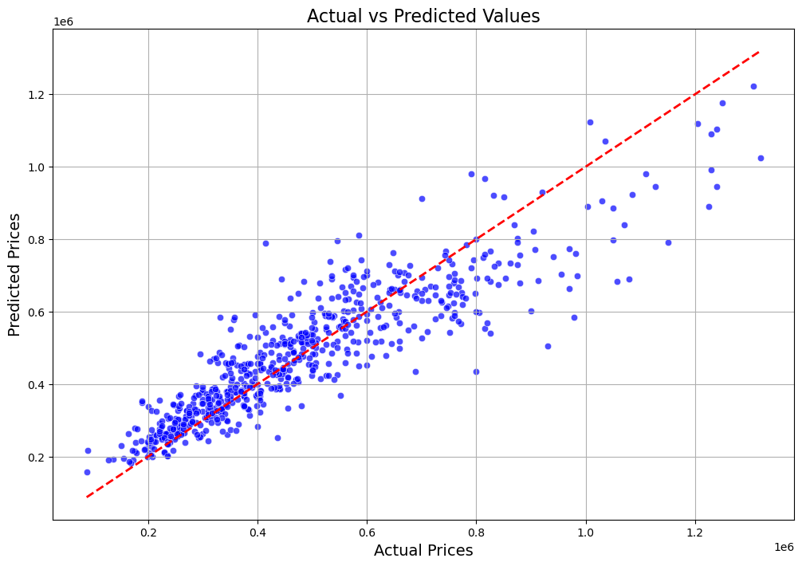

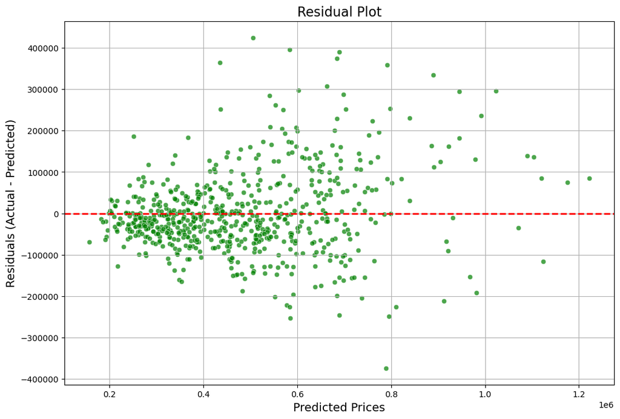

```python
# Scatter Plot: Actual vs Predicted
plt.figure(figsize=(12, 8))  # Set figure size
sns.scatterplot(x=y_test, y=y_pred, alpha=0.7, color='blue')
plt.plot([y_test.min(), y_test.max()], [y_test.min(), y_test.max()], '--r', linewidth=2)
plt.title("Actual vs Predicted Values", fontsize=16)
plt.xlabel("Actual Prices", fontsize=14)
plt.ylabel("Predicted Prices", fontsize=14)
plt.grid(True)
plt.show()

# Residual Plot
residuals = y_test - y_pred
plt.figure(figsize=(12, 8))  # Set figure size
sns.scatterplot(x=y_pred, y=residuals, alpha=0.7, color='green')
plt.axhline(0, linestyle='--', color='red', linewidth=2)
plt.title("Residual Plot", fontsize=16)
plt.xlabel("Predicted Prices", fontsize=14)
plt.ylabel("Residuals (Actual - Predicted)", fontsize=14)
plt.grid(True)
plt.show()
```

# HYPERPARAMETER GRID TO INCREASE THE SCORE OF THE XGBOOST MODEL

```python
# Data Preparation (Ensure X and y are properly set up)
X = new_data.drop(columns=['price'])
y = new_data['price']

# Encoding Categorical Variables
X = pd.get_dummies(X, columns=['country', 'waterfront', 'view', 'condition'], drop_first=True)

# Train-Test Split
X_train, X_test, y_train, y_test = train_test_split(X, y, test_size=0.2, random_state=42)

# Align Indices of X_train and y_train in case of any mismatch
X_train, y_train = X_train.align(y_train, join='inner', axis=0)

# Initialize XGBoost Model
xgboost_model = XGBRegressor(random_state=42)
```

```python
# Define Hyperparameter Grid
param_grid_xgb = {
    'n_estimators': [100, 200, 300],
    'learning_rate': [0.01, 0.1, 0.2],
    'max_depth': [4, 6, 8],
    'min_child_weight': [1, 3, 5],
    'subsample': [0.8, 1.0],
    'colsample_bytree': [0.8, 1.0]
}

# GridSearchCV Setup
grid_search_xgb = GridSearchCV(
    estimator=xgboost_model,
    param_grid=param_grid_xgb,
    cv=5,
    scoring='r2',
    verbose=2,
    n_jobs=-1
)

# Train the GridSearchCV
grid_search_xgb.fit(X_train, y_train)
```

```
Fitting 5 folds for each of 324 candidates, totalling 1620 fits
```

```
GridSearchCV(cv=5,
             estimator=XGBRegressor(base_score=None, booster=None,
                                    callbacks=None, colsample_bylevel=None,
                                    colsample_bynode=None,
                                    colsample_bytree=None, device=None,
                                    early_stopping_rounds=None,
                                    enable_categorical=False, eval_metric=None,
                                    feature_types=None, gamma=None,
                                    grow_policy=None, importance_type=None,
                                    interaction_constraints=None,
                                    learning_rate=None, m...
                                    min_child_weight=None, missing=nan,
                                    monotone_constraints=None,
                                    multi_strategy=None, n_estimators=None,
                                    n_jobs=None, num_parallel_tree=None,
                                    random_state=42, ...),
             n_jobs=-1,
             param_grid={'colsample_bytree': [0.8, 1.0],
                         'learning_rate': [0.01, 0.1, 0.2],
                         'max_depth': [4, 6, 8], 'min_child_weight': [1, 3, 5],
                         'n_estimators': [100, 200, 300],
                         'subsample': [0.8, 1.0]},
             scoring='r2', verbose=2)
```

```python
# Best Parameters
best_params_xgb = grid_search_xgb.best_params_
print("Best Parameters for XGBoost:", best_params_xgb)

# Best Estimator
best_xgboost_model = grid_search_xgb.best_estimator_
```

```
Best Parameters for XGBoost: {'colsample_bytree': 0.8, 'learning_rate': 0.1, 'max_depth': 4, 'min_child_weight': 5, 'n_estimators': 300, 'subsample': 1.0}
```

### RESULT OF THE XGBOOST MODEL AFTER HYPERPARAMETER GRID

```python
# Evaluate Best Model on Test Data
y_pred_xgb = best_xgboost_model.predict(X_test)
mse_xgb = mean_squared_error(y_test, y_pred_xgb)
rmse_xgb = np.sqrt(mse_xgb)
mae_xgb = mean_absolute_error(y_test, y_pred_xgb)
r2_xgb = r2_score(y_test, y_pred_xgb)

# Print Results for XGBoost
print("\nTuned XGBoost Model Evaluation:")
print(f"Mean Squared Error (MSE): {mse_xgb:.2f}")
print(f"Root Mean Squared Error (RMSE): {rmse_xgb:.2f}")
print(f"Mean Absolute Error (MAE): {mae_xgb:.2f}")
print(f"R-squared Score (R²): {r2_xgb:.2f}")
```

```
Tuned XGBoost Model Evaluation:
Mean Squared Error (MSE): 8578491313.31
Root Mean Squared Error (RMSE): 92620.15
Mean Absolute Error (MAE): 64922.16
R-squared Score (R²): 0.83
```

### SCATTER AND RESIDUAL PLOT

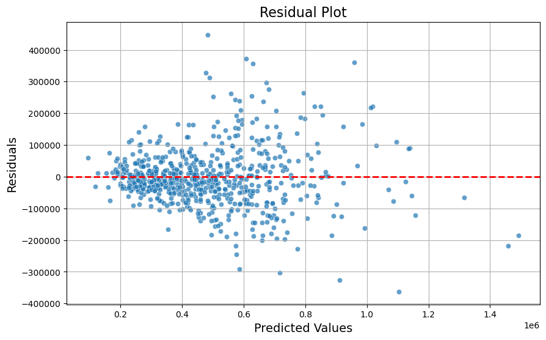

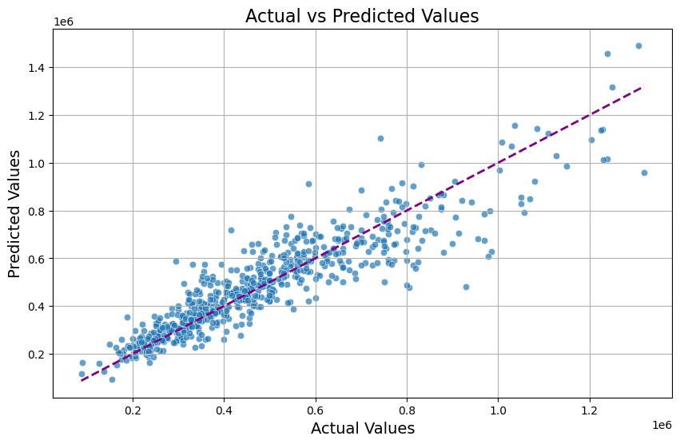

```python
# Residual Plot
residuals = y_test - y_pred_xgb

plt.figure(figsize=(10, 6))
sns.scatterplot(x=y_pred_xgb, y=residuals, alpha=0.7)
plt.axhline(y=0, color='r', linestyle='--', linewidth=2)
plt.title("Residual Plot", fontsize=16)
plt.xlabel("Predicted Values", fontsize=14)
plt.ylabel("Residuals", fontsize=14)
plt.grid(True)
plt.show()

# Scatter Plot for Actual vs Predicted Values
plt.figure(figsize=(10, 6))
sns.scatterplot(x=y_test, y=y_pred_xgb, alpha=0.7)
plt.plot([y_test.min(), y_test.max()], [y_test.min(), y_test.max()], color='purple', linestyle='--', linewidth=2)
plt.title("Actual vs Predicted Values", fontsize=16)
plt.xlabel("Actual Values", fontsize=14)
plt.ylabel("Predicted Values", fontsize=14)
plt.grid(True)
plt.show()
```